##### Recep Arda Kaya - 435060

# Principal Component Analysis to Cardiovascular Disease Dataset

## Objective

[output not shown]

## Data

Due to more practical explanation, I am going to use [Cardiovascular Disease dataset](https://www.kaggle.com/sulianova/cardiovascular-disease-dataset)

1) Review of the Data

1) a - Missing Value Check

1) b - Descriptive Statistics of Data

1) c - Univariate Variable Analysis

2) PCA

2) a - Defining "X" and "Y" variables

2) c - Principal Component Analysis

2) d - Total and Explained Variance

3) Inference

4) References

## Review of the Data

```python
!pip install -U scikit-learn
```

[output not shown]

[output not shown]

```python
## Necessary libraries imported
import numpy as np
import matplotlib.pyplot as plt
import pandas as pd
import seaborn as sns
from sklearn.model_selection import train_test_split, GridSearchCV, cross_val_score
from sklearn.metrics import confusion_matrix,accuracy_score
from sklearn.decomposition import PCA,KernelPCA
from sklearn.preprocessing import RobustScaler
from sklearn.manifold import LocallyLinearEmbedding
from sklearn.tree import DecisionTreeClassifier

import warnings
warnings.filterwarnings("ignore")
```

```python
data = pd.read_csv(r'C:\Users\Arda\Downloads\cardio_train.csv', sep=";" )

data.head()
```

|  | id | age | gender | height | weight | ap_hi | ap_lo | cholesterol | gluc | smoke | alco | active | cardio |
| --- | --- | --- | --- | --- | --- | --- | --- | --- | --- | --- | --- | --- | --- |
| 0 | 0 | 18393 | 2 | 168 | 62.0 | 110 | 80 | 1 | 1 | 0 | 0 | 1 | 0 |
| 1 | 1 | 20228 | 1 | 156 | 85.0 | 140 | 90 | 3 | 1 | 0 | 0 | 1 | 1 |
| 2 | 2 | 18857 | 1 | 165 | 64.0 | 130 | 70 | 3 | 1 | 0 | 0 | 0 | 1 |
| 3 | 3 | 17623 | 2 | 169 | 82.0 | 150 | 100 | 1 | 1 | 0 | 0 | 1 | 1 |
| 4 | 4 | 17474 | 1 | 156 | 56.0 | 100 | 60 | 1 | 1 | 0 | 0 | 0 | 0 |

```python
data.dtypes
```

```
id               int64
age              int64
gender           int64
height           int64
weight         float64
ap_hi            int64
ap_lo            int64
cholesterol      int64
gluc             int64
smoke            int64
alco             int64
active           int64
cardio           int64
dtype: object
```

### Missing Value Check

```python
data.isnull().sum()
```

```
id             0
age            0
gender         0
height         0
weight         0
ap_hi          0
ap_lo          0
cholesterol    0
gluc           0
smoke          0
alco           0
active         0
cardio         0
dtype: int64
```

### Descriptive Statistics of Data

```python
data.describe()
```

|  | id | age | gender | height | weight | ap_hi | ap_lo | cholesterol | gluc | smoke | alco | active | cardio |
| --- | --- | --- | --- | --- | --- | --- | --- | --- | --- | --- | --- | --- | --- |
| count | 70000.000000 | 70000.000000 | 70000.000000 | 70000.000000 | 70000.000000 | 70000.000000 | 70000.000000 | 70000.000000 | 70000.000000 | 70000.000000 | 70000.000000 | 70000.000000 | 70000.000000 |
| mean | 49972.419900 | 19468.865814 | 1.349571 | 164.359229 | 74.205690 | 128.817286 | 96.630414 | 1.366871 | 1.226457 | 0.088129 | 0.053771 | 0.803729 | 0.499700 |
| std | 28851.302323 | 2467.251667 | 0.476838 | 8.210126 | 14.395757 | 154.011419 | 188.472530 | 0.680250 | 0.572270 | 0.283484 | 0.225568 | 0.397179 | 0.500003 |
| min | 0.000000 | 10798.000000 | 1.000000 | 55.000000 | 10.000000 | -150.000000 | -70.000000 | 1.000000 | 1.000000 | 0.000000 | 0.000000 | 0.000000 | 0.000000 |
| 25% | 25006.750000 | 17664.000000 | 1.000000 | 159.000000 | 65.000000 | 120.000000 | 80.000000 | 1.000000 | 1.000000 | 0.000000 | 0.000000 | 1.000000 | 0.000000 |
| 50% | 50001.500000 | 19703.000000 | 1.000000 | 165.000000 | 72.000000 | 120.000000 | 80.000000 | 1.000000 | 1.000000 | 0.000000 | 0.000000 | 1.000000 | 0.000000 |
| 75% | 74889.250000 | 21327.000000 | 2.000000 | 170.000000 | 82.000000 | 140.000000 | 90.000000 | 2.000000 | 1.000000 | 0.000000 | 0.000000 | 1.000000 | 1.000000 |
| max | 99999.000000 | 23713.000000 | 2.000000 | 250.000000 | 200.000000 | 16020.000000 | 11000.000000 | 3.000000 | 3.000000 | 1.000000 | 1.000000 | 1.000000 | 1.000000 |

### Univariate Variable Analysis

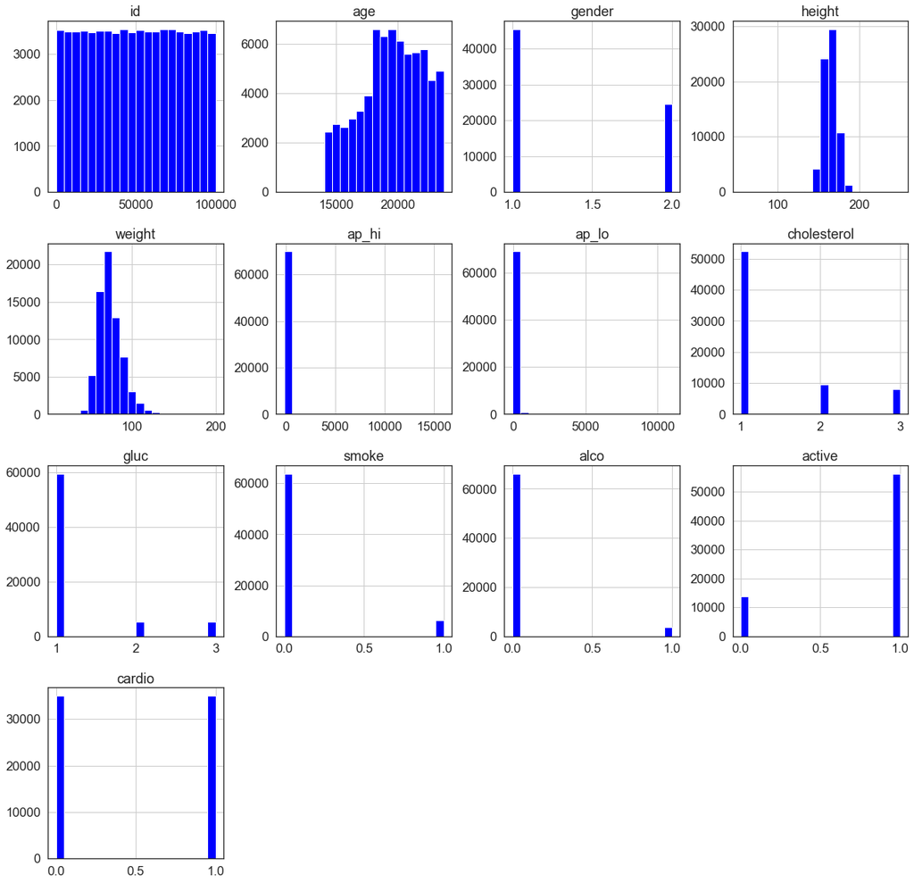

```python
sns.set(style='white',font_scale=1.5, rc={'figure.figsize':(20,20)})
ax=data.hist(bins=20,color='blue')
```

##### According to figure above, we can observe there is a balance among cardio variable. It is very important for an accurate study. In imbalance situation, we can assume that before prediction, our accuracy score will be quite higher. For a better study we have to be sure about balance between our "y variable" before prediction.

# PCA

### Defining "X" and "Y" variables

```python
x=data.drop(['cardio'],axis=1)
y=data['cardio']
```

```python
scaler=RobustScaler()
x = scaler.fit_transform(x)
```

### Principal Component Analysis

```
Dimensionality reduction is way to reduce the complexity of a model and avoid overfitting. There are two main categories of dimensionality reduction: feature selection and feature extraction. Via feature selection, we select a subset of the original features, whereas in feature extraction, we derive information from the feature set to construct a new feature subspace

Principal Component Analysis (PCA) algorithm used to compress a dataset onto a lower-dimensional feature subspace with the goal of maintaining most of the relevant information.

PCA helps us to identify patterns in data based on the correlation between features. In a nutshell, PCA aims to find the directions of maximum variance in high-dimensional data and projects it onto a new subspace with equal or fewer dimensions than the original one.
```

### Total and Explained Variance

```
The variance explained ratio of an eigenvalue λ_j is simply the fraction of an eigenvalue λ_j and the total sum of the eigenvalues
```

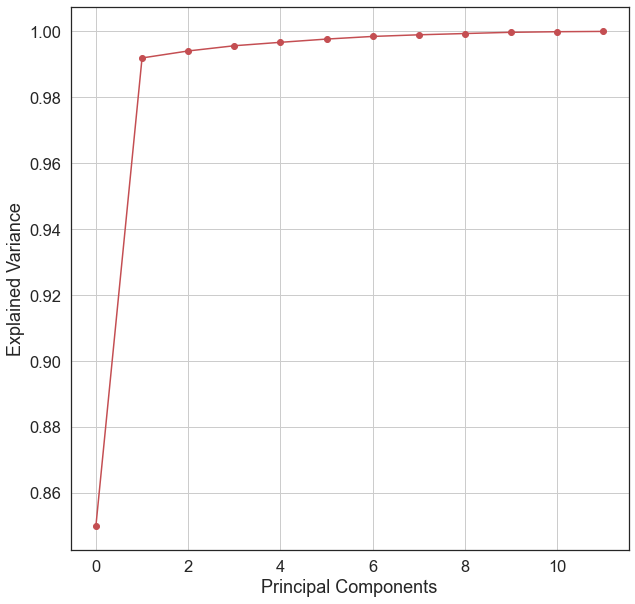

```python
pca=PCA()
x_pca = pca.fit_transform(x)
plt.figure(figsize=(10,10))
plt.ylabel('Explained Variance')
plt.xlabel('Principal Components')
plt.plot(np.cumsum(pca.explained_variance_ratio_), 'ro-')
plt.grid()
```

##### explained_variance*ratio* returns the percentage of variance explained by each of the selected components. The resulting plot indicates that the first principal component alone accounts for approximately 85% of the variance and we can see that 2 principal component will be best for our model

```python
def show_components(num_component):
    print(f"Percent explained variance: {pca.explained_variance_ratio_[num_component-1]*100:.4f}","%")
```

```python
show_components(1)
show_components(2)
```

```
Percent explained variance: 85.0085 %
Percent explained variance: 14.1860 %
```

##### According to results above, we can clearly see first 2 components are highly explanatory for our data and other components may be negligible

```python
pca = PCA(n_components=2)
pca_result = pca.fit_transform(x)
```

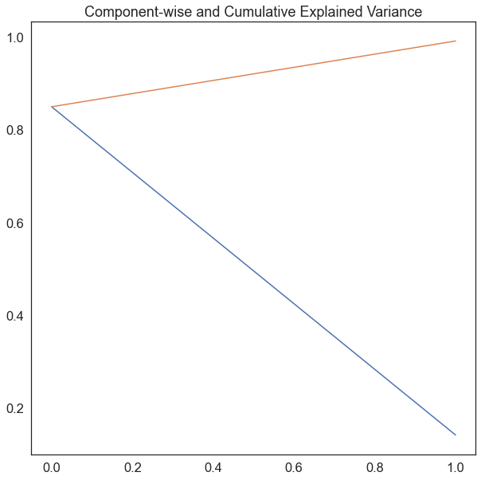

```python
plt.figure(figsize=(10,10))
plt.plot(range(2), pca.explained_variance_ratio_)
plt.plot(range(2), np.cumsum(pca.explained_variance_ratio_))
plt.title("Component-wise and Cumulative Explained Variance")
```

# Inference

##### When reducing the dimensions of data, it’s important not to lose more information than is necessary. The variation in a data set can be seen as representing the information that we would like to keep. Principal Component Analysis (PCA) is a well-established mathematical technique for reducing the dimensionality of data, while keeping as much variation as possible.

# References

https://towardsdatascience.com/a-one-stop-shop-for-principal-component-analysis-5582fb7e0a9c